# GH1044372_Into_AI_ML

**Personal Information**

1. Name:- Om Dipak Patil
2. GH Number:- GH1044372
3. M505C Intro to AI and Machine Learning.

**Predictive Modeling & Intelligent Customer Spending Analysis for Focused Financial Insights.**

**Business Problem:-** To stay profitable and relevant today's cutthroat retail and financial sectors, organizations need to have a through understanding of consumer spending patterns. Consumers vary widely in how they allocate thier income between essenstials. Some customers are big spenders who spend larg amout of their income, on the other hand others manage thir money vary carefully. to tailor financial products, marketing strategies and customer experiences for the right market, businesses need to aware of these developments.

To address this businesses can classify customersd into low and high spenders according to their attributes using Machine learning analysis. These model help with targeted marketing , better customer segementation, personalized product recommendations, and more informed credit decision by forecasting.

**Introduction:-** To ubnderstand that the consumer finance problem and behavior is essential for companies looking to increase sales and establish enduring partnership in today's cutthrot market. Differentiating between high and low spenders is crucial since customers differ greatly in how they divide their income. Businesses can optimize business outcomes and customize tactics that meet client expectations by accurately recognizing these categories.

Using metrics like income, total expenses, debt ratio, rent ratio and savings, this project uses approch of ML Machine Learning to forecast consumer spending patterns. We will find the accuracy, precision, F1, recall and ROC_AUC of server models, including Logistic Regression, Decision Tree, K-Nearest Neighbors, and by PyTorch implementations, were assessed during training. the project's successful client classification yields information that help direct risk management plans, customized product offerings, and target marketing.

**Data scource:**

https://www.kaggle.com/datasets/shriyashjagtap/indian-personal-finance-and-spending-habits

**Objectives:**

1. Determine the main causes of both high and low spending behavior by analyzing consumer spending trends using demographic, lifestyle, and financial characteristics.
2. Create and evaluate prediction models (Decision Tree, KNN TenserFlow, PyTorch, and Logistic Regression) to categorize clients into high and low spender groups.
3. To guarantee solid and trustworthy predicitions, assess model performance using accuracy, precision, recall, F1 score, and AUC.
4. Use feature importance to identify key factors impacting spending patterns.
5. Create company information to help with consumer segmentation, tailored finacncial advise, and focused marketing campaigns.

Impoting all the libraries.

```python
import pandas as pd # Pandas and numpy is very strong doundation for data analysis.
import numpy as np
import matplotlib.pyplot as plt # This lib is used to show the visualization in our project
import seaborn as sns
from sklearn.preprocessing import StandardScaler, MinMaxScaler, LabelEncoder, OneHotEncoder # This lib is widely used for Feature Scalling in ML
from sklearn.model_selection import train_test_split, GridSearchCV, RandomizedSearchCV
from sklearn.impute import SimpleImputer # We used this for handling missing values in our datset
from imblearn.over_sampling import SMOTE # SMOTE (Synthetic Minority Oversampling Technique) is used to handle class imbalnce
import warnings
warnings.filterwarnings('ignore')
```

Here we load the datset thorigh csv file or we can directly mount our dataset and further we displayed that dataset.

```python
df = pd.read_csv("/content/drive/MyDrive/Colab Notebooks/data (1).csv")
df
```

|  | Income | Age | Dependents | Occupation | City_Tier | Rent | Loan_Repayment | Insurance | Groceries | Transport | ... | Desired_Savings | Disposable_Income | Potential_Savings_Groceries | Potential_Savings_Transport | Potential_Savings_Eating_Out | Potential_Savings_Entertainment | Potential_Savings_Utilities | Potential_Savings_Healthcare | Potential_Savings_Education | Potential_Savings_Miscellaneous |
| --- | --- | --- | --- | --- | --- | --- | --- | --- | --- | --- | --- | --- | --- | --- | --- | --- | --- | --- | --- | --- | --- |
| 0 | 44637.249636 | 49 | 0 | Self_Employed | Tier_1 | 13391.174891 | 0.000000 | 2206.490129 | 6658.768341 | 2636.970696 | ... | 6200.537192 | 11265.627707 | 1685.696222 | 328.895281 | 465.769172 | 195.151320 | 678.292859 | 67.682471 | 0.000000 | 85.735517 |
| 1 | 26858.596592 | 34 | 2 | Retired | Tier_2 | 5371.719318 | 0.000000 | 869.522617 | 2818.444460 | 1543.018778 | ... | 1923.176434 | 9676.818733 | 540.306561 | 119.347139 | 141.866089 | 234.131168 | 286.668408 | 6.603212 | 56.306874 | 97.388606 |
| 2 | 50367.605084 | 35 | 1 | Student | Tier_3 | 7555.140763 | 4612.103386 | 2201.800050 | 6313.222081 | 3221.396403 | ... | 7050.360422 | 13891.450624 | 1466.073984 | 473.549752 | 410.857129 | 459.965256 | 488.383423 | 7.290892 | 106.653597 | 138.542422 |
| 3 | 101455.600247 | 21 | 0 | Self_Employed | Tier_3 | 15218.340037 | 6809.441427 | 4889.418087 | 14690.149363 | 7106.130005 | ... | 16694.965136 | 31617.953615 | 1875.932770 | 762.020789 | 1241.017448 | 320.190594 | 1389.815033 | 193.502754 | 0.000000 | 296.041183 |
| 4 | 24875.283548 | 52 | 4 | Professional | Tier_2 | 4975.056710 | 3112.609398 | 635.907170 | 3034.329665 | 1276.155163 | ... | 1874.099434 | 6265.700532 | 788.953124 | 68.160766 | 61.712505 | 187.173750 | 194.117130 | 47.294591 | 67.388120 | 96.557076 |
| ... | ... | ... | ... | ... | ... | ... | ... | ... | ... | ... | ... | ... | ... | ... | ... | ... | ... | ... | ... | ... | ... |
| 19995 | 40913.466178 | 51 | 4 | Self_Employed | Tier_1 | 12274.039853 | 7703.854895 | 1646.799940 | 5477.403246 | 2084.230191 | ... | 1163.318310 | 1163.318310 | 597.028412 | 287.315050 | 347.658355 | 145.843671 | 212.833325 | 44.900294 | 98.765527 | 190.591917 |
| 19996 | 90295.772638 | 21 | 1 | Student | Tier_2 | 18059.154528 | 0.000000 | 2770.589626 | 13118.222419 | 4633.108332 | ... | 10613.589598 | 30725.175170 | 3854.823822 | 359.602765 | 911.269461 | 424.064224 | 1555.548024 | 129.655981 | 239.445622 | 351.436046 |
| 19997 | 40604.567373 | 30 | 1 | Professional | Tier_2 | 8120.913475 | 8089.612716 | 1548.564328 | 6018.276121 | 2493.563674 | ... | 2267.905134 | 2267.905134 | 1385.511100 | 379.927216 | 138.209465 | 297.695658 | 824.565267 | 57.891000 | 72.728663 | 122.569277 |
| 19998 | 118157.817240 | 27 | 2 | Professional | Tier_1 | 35447.345172 | 12345.910538 | 4735.672471 | 16392.438426 | 8248.242279 | ... | 10603.684814 | 10603.684814 | 3217.771594 | 2265.865033 | 726.247719 | 273.912367 | 859.230004 | 98.961780 | 92.189012 | 569.811212 |
| 19999 | 8209.249769 | 62 | 3 | Professional | Tier_1 | 2462.774931 | 1120.881704 | 276.376556 | 969.916908 | 460.435438 | ... | 531.044006 | 860.350559 | 261.160294 | 124.057428 | 25.940556 | 35.238134 | 94.909265 | 1.685026 | 4.837574 | 12.766302 |

20000 rows × 27 columns

Now This function is used to displays the number of rows and columns, each column's name, and their number of values that are missing from each column, Furhermore, it indicates the memory usage of the datset and which type of that.

```python
df.info()
```

```
<class 'pandas.core.frame.DataFrame'>
RangeIndex: 20000 entries, 0 to 19999
Data columns (total 27 columns):
 #   Column                           Non-Null Count  Dtype
---  ------                           --------------  -----
 0   Income                           20000 non-null  float64
 1   Age                              20000 non-null  int64
 2   Dependents                       20000 non-null  int64
 3   Occupation                       20000 non-null  object
 4   City_Tier                        20000 non-null  object
 5   Rent                             20000 non-null  float64
 6   Loan_Repayment                   20000 non-null  float64
 7   Insurance                        20000 non-null  float64
 8   Groceries                        20000 non-null  float64
 9   Transport                        20000 non-null  float64
```

[output cut: 19 more lines]

**Exploratory Data Analysis (EDA)**

EDA is crucial since it aids in our comprehension of the data. It helps to select the best features for modelling, identifies error or missing values, and display the patterns, trends, and correlation between features.

```python
print("Dataset shape:", df.shape)
```

```
Dataset shape: (20000, 27)
```

Here are the list of columns that are present in our dataset.

```python
print("Columns in dataset:", df.columns)
```

```
Columns in dataset: Index(['Income', 'Age', 'Dependents', 'Occupation', 'City_Tier', 'Rent',
       'Loan_Repayment', 'Insurance', 'Groceries', 'Transport', 'Eating_Out',
       'Entertainment', 'Utilities', 'Healthcare', 'Education',
       'Miscellaneous', 'Desired_Savings_Percentage', 'Desired_Savings',
       'Disposable_Income', 'Potential_Savings_Groceries',
       'Potential_Savings_Transport', 'Potential_Savings_Eating_Out',
       'Potential_Savings_Entertainment', 'Potential_Savings_Utilities',
       'Potential_Savings_Healthcare', 'Potential_Savings_Education',
       'Potential_Savings_Miscellaneous'],
      dtype='object')
```

Next we will check the missing values in our datset.

```python
missing_values = df.isnull().sum()
print("Missing values per column:\n", missing_values)
```

```
Missing values per column:
 Income                             0
Age                                0
Dependents                         0
Occupation                         0
City_Tier                          0
Rent                               0
Loan_Repayment                     0
Insurance                          0
Groceries                          0
Transport                          0
Eating_Out                         0
Entertainment                      0
Utilities                          0
Healthcare                         0
Education                          0
Miscellaneous                      0
Desired_Savings_Percentage         0
Desired_Savings                    0
Disposable_Income                  0
Potential_Savings_Groceries        0
Potential_Savings_Transport        0
Potential_Savings_Eating_Out       0
Potential_Savings_Entertainment    0
Potential_Savings_Utilities        0
Potential_Savings_Healthcare       0
Potential_Savings_Education        0
Potential_Savings_Miscellaneous    0
dtype: int64
```

Unfortunately, There is no missing values in our entire datset. So we inject some null values in smoe columns to identify the precoess of handling with missing values.

```python
# Insert Null values to unclean data
np.random.seed(42)
columns_to_nan = [
    'Income', 'Age', 'Rent', 'Groceries', 'Transport',
    'Eating_Out', 'Entertainment', 'Utilities', 'Healthcare',
    'Education', 'Miscellaneous', 'Desired_Savings_Percentage',
    'Potential_Savings_Groceries', 'Potential_Savings_Transport'
]
missing_percentage = 0.1
for col in columns_to_nan:
    df.loc[df.sample(frac=missing_percentage).index, col] = np.nan
print(df[columns_to_nan].isnull().sum())
```

```
Income                         2000
Age                            2000
Rent                           2000
Groceries                      2000
Transport                      2000
Eating_Out                     2000
Entertainment                  2000
Utilities                      2000
Healthcare                     2000
Education                      2000
Miscellaneous                  2000
Desired_Savings_Percentage     2000
Potential_Savings_Groceries    2000
Potential_Savings_Transport    2000
dtype: int64
```

Here, we deal with all missing values in the dataset by calculitng median for every column.

```python
from sklearn.impute import SimpleImputer
# List of columns with missing values
columns_with_nan = [
    'Income', 'Age', 'Rent', 'Groceries', 'Transport',
    'Eating_Out', 'Entertainment', 'Utilities', 'Healthcare',
    'Education', 'Miscellaneous', 'Desired_Savings_Percentage',
    'Potential_Savings_Groceries', 'Potential_Savings_Transport'
]

# Create a SimpleImputer object to fill missing values with median
imputer = SimpleImputer(strategy='median')

# Fit and transform the data
df[columns_with_nan] = imputer.fit_transform(df[columns_with_nan])

missing_values = df.isnull().sum()
print("Missing values per column:\n", missing_values)
```

```
Missing values per column:
 Income                             0
Age                                0
Dependents                         0
Occupation                         0
City_Tier                          0
Rent                               0
Loan_Repayment                     0
Insurance                          0
Groceries                          0
Transport                          0
Eating_Out                         0
Entertainment                      0
Utilities                          0
Healthcare                         0
Education                          0
Miscellaneous                      0
Desired_Savings_Percentage         0
Desired_Savings                    0
Disposable_Income                  0
Potential_Savings_Groceries        0
Potential_Savings_Transport        0
Potential_Savings_Eating_Out       0
Potential_Savings_Entertainment    0
Potential_Savings_Utilities        0
Potential_Savings_Healthcare       0
Potential_Savings_Education        0
Potential_Savings_Miscellaneous    0
dtype: int64
```

**Descriptive Statistics:-**

In Descriptive Statistics for each dataset's numerical columns is given by this function the df.describe(). it contains important metrics including min and max values, the25th and 50th (median), 75 percentiles.

```python
df.describe()
```

|  | Income | Age | Dependents | Rent | Loan_Repayment | Insurance | Groceries | Transport | Eating_Out | Entertainment | ... | Desired_Savings | Disposable_Income | Potential_Savings_Groceries | Potential_Savings_Transport | Potential_Savings_Eating_Out | Potential_Savings_Entertainment | Potential_Savings_Utilities | Potential_Savings_Healthcare | Potential_Savings_Education | Potential_Savings_Miscellaneous |
| --- | --- | --- | --- | --- | --- | --- | --- | --- | --- | --- | --- | --- | --- | --- | --- | --- | --- | --- | --- | --- | --- |
| count | 2.000000e+04 | 20000.000000 | 20000.000000 | 20000.000000 | 20000.000000 | 20000.000000 | 20000.000000 | 20000.000000 | 20000.000000 | 20000.000000 | ... | 20000.000000 | 20000.000000 | 20000.000000 | 20000.000000 | 20000.000000 | 20000.000000 | 20000.000000 | 20000.000000 | 20000.000000 | 20000.000000 |
| mean | 4.051012e+04 | 41.005100 | 1.995950 | 8835.150853 | 2049.800292 | 1455.028761 | 5058.145019 | 2629.539573 | 1416.628130 | 1407.895210 | ... | 4982.878416 | 10647.367257 | 876.457260 | 456.847915 | 254.963280 | 254.031058 | 436.332808 | 41.524964 | 62.417083 | 144.904987 |
| std | 3.823104e+04 | 12.881971 | 1.417616 | 8775.653746 | 4281.789941 | 1492.938435 | 4819.152896 | 2563.682732 | 1394.846277 | 1423.854858 | ... | 7733.468188 | 11740.637289 | 981.020970 | 514.826067 | 296.047943 | 299.973590 | 503.200658 | 53.152458 | 98.842656 | 169.160951 |
| min | 1.371763e+03 | 18.000000 | 0.000000 | 235.365692 | 0.000000 | 30.002012 | 154.078240 | 102.186905 | 39.437523 | 45.421469 | ... | 0.000000 | -5400.788673 | 16.575501 | 8.268076 | 3.797926 | 3.121610 | 6.200297 | 0.001238 | 0.000000 | 2.091973 |
| 25% | 1.873957e+04 | 31.000000 | 1.000000 | 3901.302468 | 0.000000 | 580.204749 | 2315.936153 | 1201.753701 | 625.211913 | 628.206912 | ... | 1224.932636 | 3774.894323 | 343.351486 | 176.022501 | 84.506870 | 84.562090 | 148.013618 | 11.037421 | 4.926210 | 47.637307 |
| 50% | 3.013522e+04 | 41.000000 | 2.000000 | 6408.652100 | 0.000000 | 1017.124681 | 3740.062090 | 1936.240297 | 1028.990488 | 1021.937975 | ... | 2155.356763 | 7224.890977 | 605.576555 | 307.125531 | 164.927660 | 164.740232 | 285.739582 | 25.202124 | 33.127987 | 93.090257 |
| 75% | 4.833926e+04 | 51.000000 | 3.000000 | 10471.911294 | 2627.142320 | 1787.160895 | 6049.837925 | 3147.880098 | 1679.881872 | 1663.346518 | ... | 6216.309609 | 13331.950716 | 1041.164241 | 543.666369 | 313.398240 | 310.927935 | 538.983703 | 52.353736 | 80.946145 | 178.257981 |
| max | 1.079728e+06 | 64.000000 | 4.000000 | 215945.674703 | 123080.682009 | 38734.932935 | 119816.898124 | 81861.503457 | 22962.605051 | 38667.368308 | ... | 245504.485208 | 377060.218482 | 34894.644404 | 12273.258242 | 5573.036433 | 6222.200913 | 8081.799518 | 1394.531049 | 3647.244243 | 4637.951137 |

8 rows × 25 columns

This functions concentartes on the dataset's columns pertaining to recvenue and expenses. For every column, it computes the mean, median, minimum, maximum, among other fundamental descriptive statistics. Understanding the normal values, ranges, volatility in income and spending is made very easier by statistics. For each and every characteristic, the algorithms also plots histograms to visually represent the distribution of values. This enables us to rapidly identify the trends, such as whether the majority of people spend similarly.

```
Descriptive Statistics for Income and Expenses:

                        Mean        Median          Min           Max
Income          40510.116446  30135.219593  1371.763472  1.079728e+06
Rent             8835.150853   6408.652100   235.365692  2.159457e+05
Loan_Repayment   2049.800292      0.000000     0.000000  1.230807e+05
Insurance        1455.028761   1017.124681    30.002012  3.873493e+04
Groceries        5058.145019   3740.062090   154.078240  1.198169e+05
Transport        2629.539573   1936.240297   102.186905  8.186150e+04
Eating_Out       1416.628130   1028.990488    39.437523  2.296261e+04
Entertainment    1407.895210   1021.937975    45.421469  3.866737e+04
Utilities        2430.570702   1762.927229    88.686417  5.115619e+04
Healthcare       1613.396737   1187.202520    53.500761  3.600153e+04
Education        2409.970637   1698.867525     0.000000  8.166509e+04
Miscellaneous     809.084519    580.605302    20.503223  1.585636e+04
```

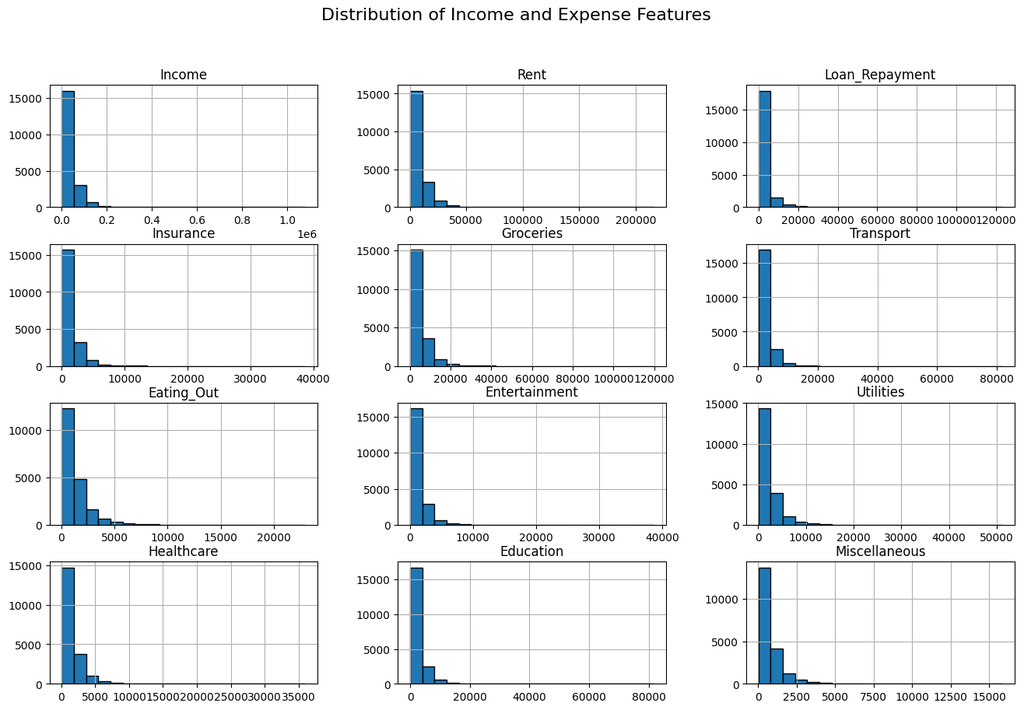

```python
income_expense_cols = [
    'Income', 'Rent', 'Loan_Repayment', 'Insurance', 'Groceries',
    'Transport', 'Eating_Out', 'Entertainment', 'Utilities',
    'Healthcare', 'Education', 'Miscellaneous'
]

desc_stats = pd.DataFrame({
    'Mean': df[income_expense_cols].mean(),
    'Median': df[income_expense_cols].median(),
    'Min': df[income_expense_cols].min(),
    'Max': df[income_expense_cols].max()
})
print("Descriptive Statistics for Income and Expenses:\n")
print(desc_stats)

df[income_expense_cols].hist(figsize=(16,10), bins=20, edgecolor='black')
plt.suptitle("Distribution of Income and Expense Features", fontsize=16)
plt.show()
```

**Correlation alalysis:**

To determine how each variable connects to the others, this method computes the correlation between all of the dataset's numerical properties. Negative values show an inverse link, whereas positive values show that as one trait rise, the other trend to rise as well. The precise correlation values are marked in each cell, and heatmap uses a color gradiesnt from (negative) to red (positive) to graphically depict these associations. This facilitates the identification of robust feature associations, which can inform feature selection, identify multicollinearity, and reval patterns in the data.

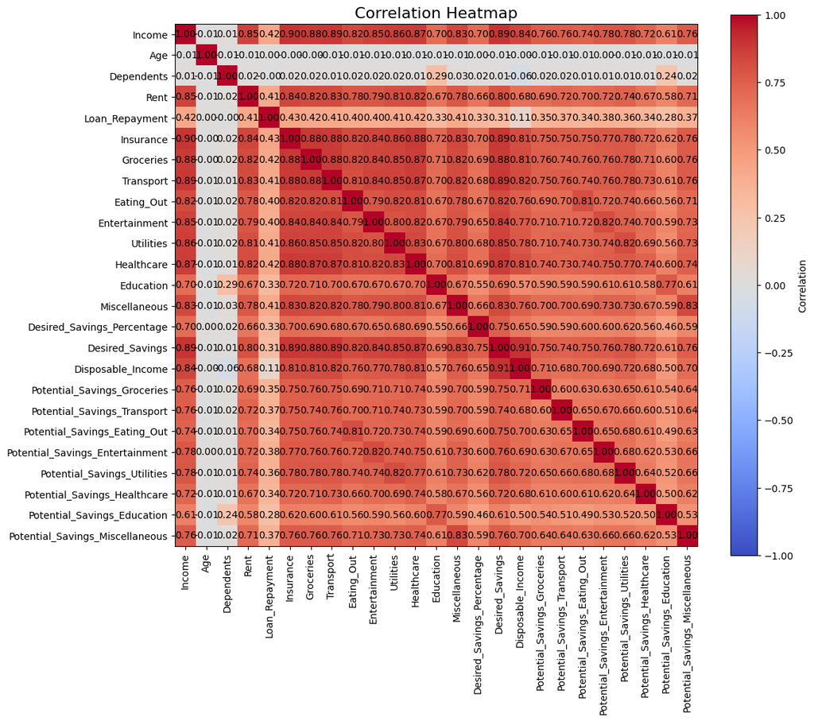

```python
numerical_cols = df.select_dtypes(include=['int64', 'float64']).columns # Select numerical columns
corr_matrix = df[numerical_cols].corr()# Compute correlation matrix
# Plot heatmap with proper scaling and annotations
plt.figure(figsize=(12,10))
plt.imshow(corr_matrix, cmap='coolwarm', vmin=-1, vmax=1)
plt.colorbar(label='Correlation')
plt.xticks(ticks=np.arange(len(corr_matrix.columns)), labels=corr_matrix.columns, rotation=90)
plt.yticks(ticks=np.arange(len(corr_matrix.columns)), labels=corr_matrix.columns)
for i in range(len(corr_matrix.columns)):# Add text annotations for each cell
    for j in range(len(corr_matrix.columns)):
        plt.text(j, i, f"{corr_matrix.iloc[i, j]:.2f}", ha='center', va='center', color='black')

plt.title("Correlation Heatmap", fontsize=16)
plt.show()
```

**High Spender Target and Feature Correlation:**

In order to determine whether a client spends more than the median, this method computes the correlation between each numerical feature and the target varaible High_Spender. It first makes sure that High_Spender and Total_Expenditure are present, generating them if needed. A dot plot is then used to display the correlations, with red dots denoting negative correlations and green dots denoting positive correlations. This facilitaes the rapid identification of the characteristics that best predict high spending behavior.

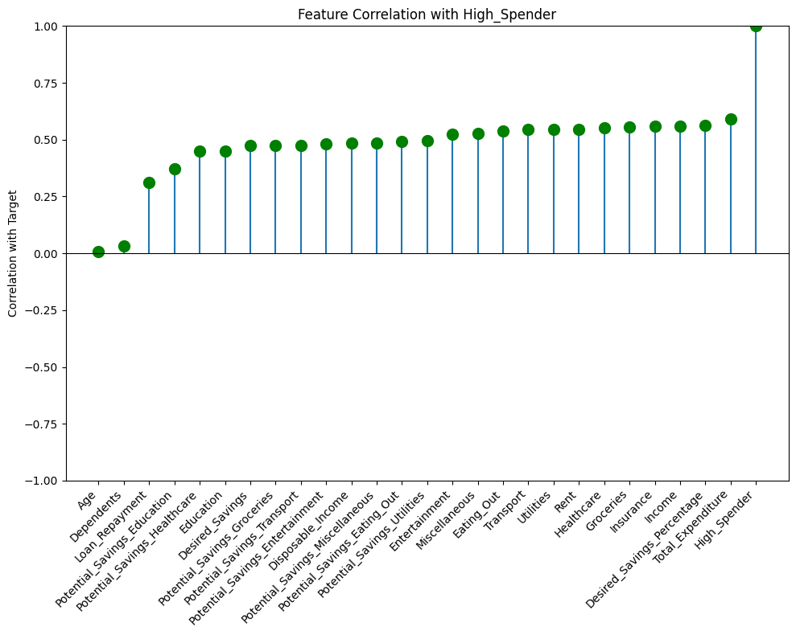

```python
# Ensure Total_Expenditure and High_Spender exist
if 'Total_Expenditure' not in df.columns:
    df['Total_Expenditure'] = df[['Rent','Loan_Repayment','Insurance','Groceries',
                                  'Transport','Eating_Out','Entertainment','Utilities',
                                  'Healthcare','Education','Miscellaneous']].sum(axis=1)

if 'High_Spender' not in df.columns:
    median_expenditure = df['Total_Expenditure'].median()
    df['High_Spender'] = (df['Total_Expenditure'] > median_expenditure).astype(int)

# Ensure target column is numeric
target_col = 'High_Spender'
if df[target_col].dtype == 'object':
    df[target_col] = df[target_col].astype('category').cat.codes

# Select numerical columns
numerical_cols = df.select_dtypes(include=['int64', 'float64']).columns

# Compute correlation with target
corr_with_target = df[numerical_cols].corr()[target_col].sort_values(ascending=True)

# Dot (lollipop-style) plot
plt.figure(figsize=(10,8))
plt.stem(corr_with_target.index, corr_with_target.values, basefmt=" ")
plt.xticks(rotation=45, ha='right')
plt.ylim(-1, 1)
plt.ylabel("Correlation with Target")
plt.title(f"Feature Correlation with {target_col}")

# Add dots colored by positive/negative correlation
for i, val in enumerate(corr_with_target.values):
    color = 'green' if val > 0 else 'red'
    plt.plot(i, val, 'o', color=color, markersize=10)

plt.axhline(0, color='black', linewidth=0.8)  # horizontal line at 0
plt.tight_layout()
plt.show()
```

**Income versus. Individual Spending Category Boxplots**

This code uses boxplots to show how income and different spending categories realte to one another. Every subplot contrasts the income distribution with a particular expense, like rent, groceries, transportion, or utilities. We may better understand consumer spending trends and pinpoint regions where spending may be abnormally high or low by looking at these boxplots.

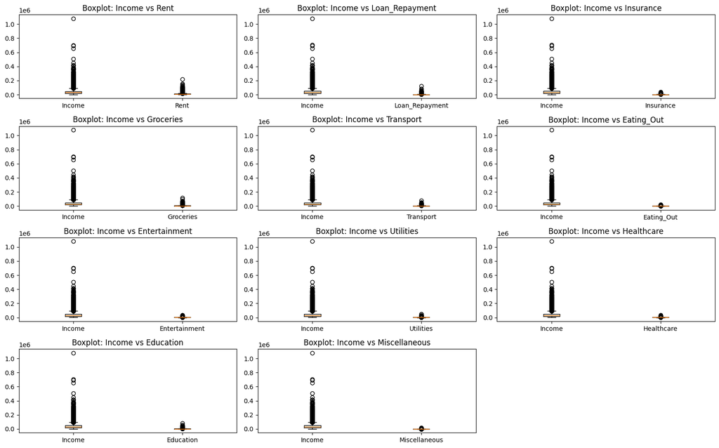

```python
spending_cols = ['Rent','Loan_Repayment','Insurance','Groceries','Transport',
                 'Eating_Out','Entertainment','Utilities','Healthcare','Education','Miscellaneous']

# Boxplots
plt.figure(figsize=(16,10))
for i, col in enumerate(spending_cols, 1):
    plt.subplot(4, 3, i)
    plt.boxplot([df['Income'], df[col]], labels=['Income', col])
    plt.title(f'Boxplot: Income vs {col}')
plt.tight_layout()
plt.show()
```

With points colored by spending class, this scatter plot illustrates the link between income and total expenses. It makes the distribution of high and low spenders across income levels easier to see.

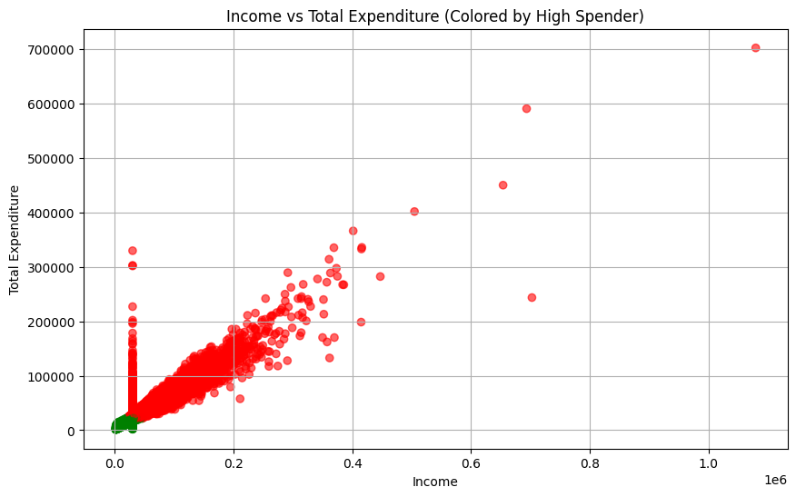

```python
# Ensure Total_Expenditure and High_Spender exist
if 'Total_Expenditure' not in df.columns:
    df['Total_Expenditure'] = df[['Rent','Loan_Repayment','Insurance','Groceries',
                                  'Transport','Eating_Out','Entertainment','Utilities',
                                  'Healthcare','Education','Miscellaneous']].sum(axis=1)

if 'High_Spender' not in df.columns:
    median_expenditure = df['Total_Expenditure'].median()
    df['High_Spender'] = (df['Total_Expenditure'] > median_expenditure).astype(int)
plt.figure(figsize=(10,6))
colors = df['High_Spender'].map({0:'green', 1:'red'})
plt.scatter(df['Income'], df['Total_Expenditure'], c=colors, alpha=0.6)
plt.xlabel("Income")
plt.ylabel("Total Expenditure")
plt.title("Income vs Total Expenditure (Colored by High Spender)")
plt.grid(True)
plt.show()
```

**Check Target Balance**

The goal variable High_Spender, which categorized clients as low or high spenders based on their overall expenditure, is examined in this stage. To rapidly dettermine which groups dominates, the distribution of these classes is first computed and shown using a bar chart. To comprehend the datset's balance, the proportion of each classes also calculated.

A balanced datset is produced by upsampling the minority class to match the majority if the ratio is large. By doing this, it is made sure that machine learning models do not start to favor the larger class.

```
High_Spender class distribution:

High_Spender
1    10000
0    10000
Name: count, dtype: int64

Percentage distribution:
High_Spender
1    50.0
0    50.0
Name: count, dtype: float64
```

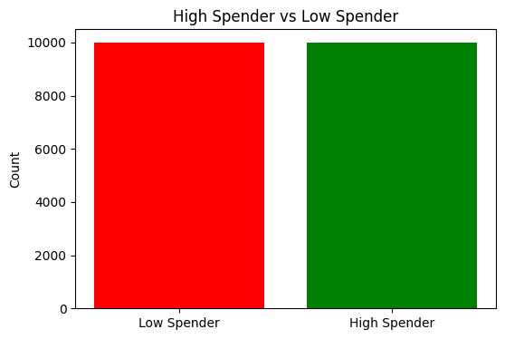

```
Imbalance ratio (majority/minority): 1.00
```

```python
# Ensure High_Spender exists
if 'High_Spender' not in df.columns:
    # Create target based on Total_Expenditure
    df['Total_Expenditure'] = df[['Rent','Loan_Repayment','Insurance','Groceries',
                                  'Transport','Eating_Out','Entertainment','Utilities',
                                  'Healthcare','Education','Miscellaneous']].sum(axis=1)
    median_expenditure = df['Total_Expenditure'].median()
    df['High_Spender'] = (df['Total_Expenditure'] > median_expenditure).astype(int)

# Check Target Balance
target_counts = df['High_Spender'].value_counts()
print("High_Spender class distribution:\n")
print(target_counts)
print(f"\nPercentage distribution:\n{target_counts/len(df)*100}")

# Optional visualization
import matplotlib.pyplot as plt
plt.figure(figsize=(6,4))
plt.bar(target_counts.index, target_counts.values, color=['green','red'])
plt.xticks([0,1], ['Low Spender','High Spender'])
plt.ylabel("Count")
plt.title("High Spender vs Low Spender")
plt.show()

# Handle Class Imbalance (if needed)
from sklearn.utils import resample

# Separate majority and minority classes
df_majority = df[df['High_Spender']==0]
df_minority = df[df['High_Spender']==1]

# Check if imbalance is significant (e.g., ratio > 1.5)
imbalance_ratio = len(df_majority) / len(df_minority)
print(f"\nImbalance ratio (majority/minority): {imbalance_ratio:.2f}")

if imbalance_ratio > 1.5:
    # Upsample minority class
    df_minority_upsampled = resample(df_minority,
                                     replace=True,    # sample with replacement
                                     n_samples=len(df_majority),  # match majority
                                     random_state=42)
    # Combine majority and upsampled minority
    df_balanced = pd.concat([df_majority, df_minority_upsampled])
    print(f"\nAfter resampling, new class distribution:\n{df_balanced['High_Spender'].value_counts()}")
else:
    df_balanced = df.copy()
#No need for oversampling, SMOTE, or any resampling.
```

**Data Preprocessing & Feature Engineering:**

For Machine Learning models, Data Preparation and Feature Engineering are essential tasks in this project. Numerical characteristics are scaled to normailze ranges, missing values are handled to gurantee completeness, and categorical variables are encoded for model compatibilitty. The feature engineering that produces significant variables that more accurately reflect consumer spending patterns. In the end, these actions enable accurate classification of high and low spenders by enhancing model accuracy.

In the absence of appropriate preprocessing and desigined features, models could perform poorly or genrate predictions that are not trustworthy.

**Fill missing values in categorical columns with mode**

```python
categorical_cols = ['Occupation', 'City_Tier']
for col in categorical_cols:
    df[col].fillna(df[col].mode()[0], inplace=True)
```

**Categorical Variable Encoding:**

In this stage, we used one hot encoding to handle categorical features like City_tier and occupation. This method creates distinct binary columns for each category by converting categorical values into numerical form. The drop first= true option was utilized which removes one category from each feature, in order to prevent multicollinearity and redundancy. The dataset is now appropriate for machine learning methods that need numerical input because it has new numeric columns that reflects the various categories after encoding.

```python
categorical_cols = ['Occupation', 'City_Tier'] # List of categorical columns to encode
df_encoded = pd.get_dummies(df, columns=categorical_cols, drop_first=True) # One-hot encode categorical columns
# Check new columns
print("Columns after one-hot encoding:\n")
print(df_encoded.columns)
```

```
Columns after one-hot encoding:

Index(['Income', 'Age', 'Dependents', 'Rent', 'Loan_Repayment', 'Insurance',
       'Groceries', 'Transport', 'Eating_Out', 'Entertainment', 'Utilities',
       'Healthcare', 'Education', 'Miscellaneous',
       'Desired_Savings_Percentage', 'Desired_Savings', 'Disposable_Income',
       'Potential_Savings_Groceries', 'Potential_Savings_Transport',
       'Potential_Savings_Eating_Out', 'Potential_Savings_Entertainment',
       'Potential_Savings_Utilities', 'Potential_Savings_Healthcare',
       'Potential_Savings_Education', 'Potential_Savings_Miscellaneous',
       'Total_Expenditure', 'High_Spender', 'Occupation_Retired',
       'Occupation_Self_Employed', 'Occupation_Student', 'City_Tier_Tier_2',
       'City_Tier_Tier_3'],
      dtype='object')
```

**Using StandardScaler for Feature Scaling**

To normalize all numerical features, we use standardScaler from sklearn.preprocessing. In order to ensure that variables like income, expenses, and savings contribute evenly during model training, this transformation rescales values so that their mean = 0 and standard deviation =1. this is crucial for gradient-based techniques like Logistic Regression and distance-based alorithms like KNN.

```python
from sklearn.preprocessing import StandardScaler, MinMaxScaler
numerical_cols = ['Income', 'Age', 'Dependents', 'Rent', 'Loan_Repayment', 'Insurance',
                  'Groceries', 'Transport', 'Eating_Out', 'Entertainment', 'Utilities',
                  'Healthcare', 'Education', 'Miscellaneous', 'Desired_Savings_Percentage',
                  'Desired_Savings', 'Disposable_Income', 'Potential_Savings_Groceries',
                  'Potential_Savings_Transport', 'Potential_Savings_Eating_Out',
                  'Potential_Savings_Entertainment', 'Potential_Savings_Utilities',
                  'Potential_Savings_Healthcare', 'Potential_Savings_Education',
                  'Potential_Savings_Miscellaneous', 'Total_Expenditure']

# 1 StandardScaler (mean=0, std=1)
scaler_std = StandardScaler()
df_encoded[numerical_cols] = scaler_std.fit_transform(df_encoded[numerical_cols])
# Check scaled data
print(df_encoded[numerical_cols].head())
```

```
     Income       Age  Dependents      Rent  Loan_Repayment  Insurance  \
0  0.107955  0.620643   -1.407998  0.519179       -0.478737   0.503356
1 -0.357088 -0.543805    0.002857 -0.394674       -0.478737  -0.392194
2  0.257846 -0.466175   -0.702570 -0.145863        0.598434   0.500215
3 -0.271380 -1.552992   -1.407998  0.727393        1.111629   2.300480
4 -0.408967  0.853532    1.413712 -0.439875        0.248222  -0.548678

   Groceries  Transport  Eating_Out  Entertainment  ...  Disposable_Income  \
0   0.332146   0.002899    0.168606       0.090102  ...           0.052661
1  -0.464761  -0.423823   -0.550074      -0.271072  ...          -0.082668
2   0.260442   0.230868   -0.277914      -0.271072  ...           0.276319
3   1.998742   1.746200    2.597929       1.018598  ...           1.786199
4  -0.419963  -0.527920   -0.518924      -0.525143  ...          -0.373215

   Potential_Savings_Groceries  Potential_Savings_Transport  \
```

[output cut: 35 more lines]

**Developing a Feature for Total Expenditure**

```python
spending_cols = [ # Define spending columns
    'Rent','Loan_Repayment','Insurance','Groceries','Transport',
    'Eating_Out','Entertainment','Utilities','Healthcare',
    'Education','Miscellaneous'
]
df_encoded['Total_Expenditure'] = df_encoded[spending_cols].sum(axis=1)

# Check result
print(df_encoded[['Income', 'Total_Expenditure']].head())
```

```
     Income  Total_Expenditure
0  0.107955           0.506832
1 -0.357088          -4.213115
2  0.257846           1.687485
3 -0.271380          16.832961
4 -0.408967          -4.270155
```

By securely managing zero or missing information, this method generates a spending ratio feature by dividing total expense by revenue. To maintain the data's cleanliness and usability, all infinites or NAN are subsituated with 0.

```python
df['Spending_Ratio'] = df['Total_Expenditure'] / df['Income'].replace(0, np.nan)
df['Spending_Ratio'] = df['Spending_Ratio'].replace([np.inf, -np.inf], np.nan).fillna(0)
print(df[['Income', 'Total_Expenditure', 'Spending_Ratio']].head())
```

```
         Income  Total_Expenditure  Spending_Ratio
0  44637.249636       33371.621929        0.747618
1  26858.596592       17153.474097        0.638659
2  50367.605084       35289.961621        0.700648
3  30135.219593       71536.514157        2.373851
4  24875.283548       18609.583016        0.748115
```

**Analysis of Income, Total Spending, and Spending Ratio**

This code correctly handles zeros and missing data to calculate total expenditure by adding up all spending categories and calculating spending ratio by dividing total expenditure by income. In order to comprehend overall spending trends and relative expenditure behavior among consumers, it then uses histogram to illustrate the distribution of income, total expanditure, and spending ratio.

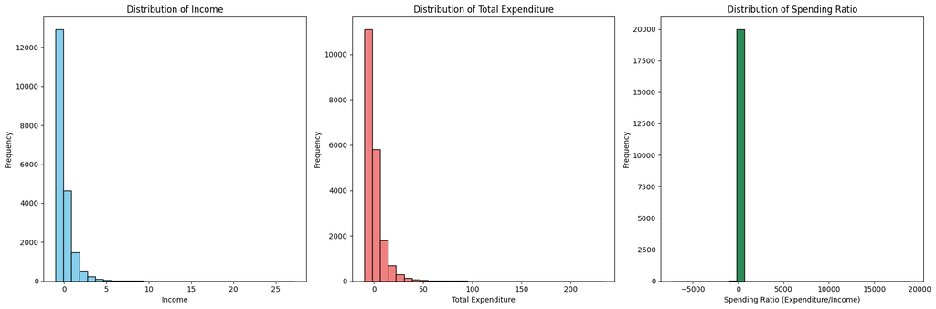

```python
spending_cols = [ # Define columns
    'Rent','Loan_Repayment','Insurance','Groceries','Transport',
    'Eating_Out','Entertainment','Utilities','Healthcare',
    'Education','Miscellaneous'
]

if 'Total_Expenditure' not in df_encoded.columns:
    df_encoded['Total_Expenditure'] = df_encoded[spending_cols].sum(axis=1)

# Create Spending_Ratio in df_encoded, avoiding division by zero
df_encoded['Spending_Ratio'] = df_encoded['Total_Expenditure'] / df_encoded['Income'].replace(0, np.nan)
df_encoded['Spending_Ratio'] = df_encoded['Spending_Ratio'].replace([np.inf, -np.inf], np.nan).fillna(0)

plt.figure(figsize=(18,6))
plt.subplot(1,3,1)
plt.hist(df_encoded['Income'], bins=30, color='skyblue', edgecolor='black')
plt.title("Distribution of Income")
plt.xlabel("Income")
plt.ylabel("Frequency")

plt.subplot(1,3,2)
plt.hist(df_encoded['Total_Expenditure'], bins=30, color='lightcoral', edgecolor='black')
plt.title("Distribution of Total Expenditure")
plt.xlabel("Total Expenditure")
plt.ylabel("Frequency")

plt.subplot(1,3,3)
plt.hist(df_encoded['Spending_Ratio'], bins=30, color='seagreen', edgecolor='black')
plt.title("Distribution of Spending Ratio")
plt.xlabel("Spending Ratio (Expenditure/Income)")
plt.ylabel("Frequency")

plt.tight_layout()
plt.show()
```

**Calculating the Debit Ratio**

This code calculates debt ratio, which displays the percentage of revenue allocated to debt repayments, by dividing loan repayments by income. It aids in determining the financial strain and ability of clients.

```python
df['Debt_Ratio'] = df['Loan_Repayment'] / df['Income']
print(df[['Income', 'Loan_Repayment', 'Debt_Ratio']].head())
```

```
         Income  Loan_Repayment  Debt_Ratio
0  44637.249636        0.000000    0.000000
1  26858.596592        0.000000    0.000000
2  50367.605084     4612.103386    0.091569
3  30135.219593     6809.441427    0.225963
4  24875.283548     3112.609398    0.125129
```

**Calculating the Rent Ratio**

This code determines the rent ratio, which shows the percentage of income allocated to housing, by dividing rent cost by income. It aids in assessing financial stress and affordability in relation to rent burden and payback capabilities.

```python
df['Rent_Ratio'] = df['Rent'] / df['Income']
print(df[['Income', 'Rent', 'Rent_Ratio']].head())
```

```
         Income          Rent  Rent_Ratio
0  44637.249636  13391.174891    0.300000
1  26858.596592   5371.719318    0.200000
2  50367.605084   7555.140763    0.150000
3  30135.219593  15218.340037    0.505002
4  24875.283548   4975.056710    0.200000
```

**Calculating the Saving Ratio**

```python
df['Savings_Ratio'] = df['Desired_Savings_Percentage'] / df['Income']
print(df[['Income', 'Desired_Savings_Percentage', 'Savings_Ratio']].head())
```

```
         Income  Desired_Savings_Percentage  Savings_Ratio
0  44637.249636                   13.890948       0.000311
1  26858.596592                    7.160376       0.000267
2  50367.605084                    8.905517       0.000177
3  30135.219593                   16.455440       0.000546
4  24875.283548                    7.533982       0.000303
```

**Transport and Grocery Efficiency Metrics**

This step computes efficiency metrics to determine how well transportation and grocery expenditures could result in possible savings. It identifies areas for cost optimization by dividing prospective saving by actual spending.

```python
# Create Efficiency Metrics
df['Groceries_Efficiency'] = df['Potential_Savings_Groceries'] / df['Groceries'].replace(0, np.nan)
df['Transport_Efficiency'] = df['Potential_Savings_Transport'] / df['Transport'].replace(0, np.nan)

# Replace any infinities or NaNs with 0
df['Groceries_Efficiency'] = df['Groceries_Efficiency'].replace([np.inf, -np.inf], 0).fillna(0)
df['Transport_Efficiency'] = df['Transport_Efficiency'].replace([np.inf, -np.inf], 0).fillna(0)

# Show first few rows
print(df[['Groceries', 'Potential_Savings_Groceries', 'Groceries_Efficiency',
          'Transport', 'Potential_Savings_Transport', 'Transport_Efficiency']].head())
```

```
      Groceries  Potential_Savings_Groceries  Groceries_Efficiency  \
0   6658.768341                  1685.696222              0.253154
1   2818.444460                   605.576555              0.214862
2   6313.222081                   605.576555              0.095922
3  14690.149363                  1875.932770              0.127700
4   3034.329665                   788.953124              0.260009

     Transport  Potential_Savings_Transport  Transport_Efficiency
0  2636.970696                   328.895281              0.124725
1  1543.018778                   119.347139              0.077347
2  3221.396403                   473.549752              0.147001
3  7106.130005                   762.020789              0.107234
4  1276.155163                    68.160766              0.053411
```

**IQR Calculation :-**

The algorithm assists in identifying anomalous data points that could need additional examination or cleansing by appluing this technique to a variety of financial measures, including income, expenses, and efficiency ratios.

```python
# Function to calculate IQR and potential outliers
def calculate_iqr(df, column):
    Q1 = df[column].quantile(0.25)
    Q3 = df[column].quantile(0.75)
    IQR = Q3 - Q1
    lower_bound = Q1 - 1.5 * IQR
    upper_bound = Q3 + 1.5 * IQR
    print(f"Column: {column}")
    print(f"Q1 (25th percentile): {Q1}")
    print(f"Q3 (75th percentile): {Q3}")
    print(f"IQR: {IQR}")
    print(f"Lower bound for outliers: {lower_bound}")
    print(f"Upper bound for outliers: {upper_bound}")

    # Identify outliers
    outliers = df[(df[column] < lower_bound) | (df[column] > upper_bound)]
    print(f"Number of potential outliers: {len(outliers)}\n")
    return IQR, lower_bound, upper_bound, outliers

# Example usage
numerical_cols = ['Income', 'Total_Expenditure', 'Spending_Ratio',
                  'Debt_Ratio', 'Rent_Ratio', 'Savings_Ratio',
                  'Groceries_Efficiency', 'Transport_Efficiency']

for col in numerical_cols:
    calculate_iqr(df, col)
```

```
Column: Income
Q1 (25th percentile): 18739.573113182294
Q3 (75th percentile): 48339.25530411666
IQR: 29599.682190934367
Lower bound for outliers: -25659.950173219255
Upper bound for outliers: 92738.77859051821
Number of potential outliers: 1463

Column: Total_Expenditure
Q1 (25th percentile): 13836.644543976121
Q3 (75th percentile): 36654.97087196623
IQR: 22818.326327990108
Lower bound for outliers: -20390.844948009042
Upper bound for outliers: 70882.4603639514
Number of potential outliers: 1288

Column: Spending_Ratio
Q1 (25th percentile): 0.6621613293658308
Q3 (75th percentile): 0.8387105457997478
IQR: 0.17654921643391697
Lower bound for outliers: 0.3973375047149554
Upper bound for outliers: 1.1035343704506233
Number of potential outliers: 1424

Column: Debt_Ratio
Q1 (25th percentile): 0.0
Q3 (75th percentile): 0.10468228146335379
IQR: 0.10468228146335379
Lower bound for outliers: -0.15702342219503068
Upper bound for outliers: 0.26170570365838447
Number of potential outliers: 131

Column: Rent_Ratio
Q1 (25th percentile): 0.19999999999999996
Q3 (75th percentile): 0.3
IQR: 0.10000000000000003
Lower bound for outliers: 0.049999999999999906
Upper bound for outliers: 0.45000000000000007
Number of potential outliers: 779

```

[output cut: 8 more lines]

```
Column: Groceries_Efficiency
Q1 (25th percentile): 0.10852847264177468
Q3 (75th percentile): 0.24118548029185521
IQR: 0.13265700765008054
Lower bound for outliers: -0.09045703883334613
Upper bound for outliers: 0.44017099176697605
Number of potential outliers: 455

Column: Transport_Efficiency
Q1 (25th percentile): 0.10803044164859552
Q3 (75th percentile): 0.24085643734720283
IQR: 0.1328259956986073
Lower bound for outliers: -0.09120855189931545
Upper bound for outliers: 0.4400954308951138
Number of potential outliers: 428
```

**Model Evaluation via Train-Test Split**

In order to preserve class balance, this code divides the datset into features (x) and target varaible (y: High_spender). It then uses an 80/20 train-test split with stratification. The test set gurantees objective performance evaluation, whereas the training set is used for learning model.

```python
from sklearn.model_selection import train_test_split
import tensorflow as tf
import numpy as np

# Replace 'High_Spender' with your target column if different
X = df_encoded.drop('High_Spender', axis=1)  # Features
y = df_encoded['High_Spender']               # Target

# Split into 80% train and 20% test
X_train, X_test, y_train, y_test = train_test_split(
    X, y, test_size=0.2, random_state=42, stratify=y
)

# Explicitly reshape y_train and y_test for Keras/TensorFlow
y_train = y_train.values.reshape(-1, 1)
y_test = y_test.values.reshape(-1, 1)

# Convert features to TensorFlow tensors
X_train_tf = tf.constant(X_train.select_dtypes(include=np.number).values, dtype=tf.float32)
X_test_tf = tf.constant(X_test.select_dtypes(include=np.number).values, dtype=tf.float32)


# Check sizes
print(f"Training set size: {X_train_tf.shape[0]} samples")
print(f"Testing set size: {X_test_tf.shape[0]} samples")
```

```
Training set size: 16000 samples
Testing set size: 4000 samples
```

**Using SMOTE to Balance Classes:**

In order to address class imbalance, this algorithm applies SMOTE to training set. By creating synthetic samples for the minority class, SMOTE ensures a more equitable distribution of classes, enhancing model performance and avoiding bias in favor of the majority class.

```python
from imblearn.over_sampling import SMOTE
import pandas as pd

# Initialize SMOTE
smote = SMOTE(random_state=42)

# Apply SMOTE to training set only
X_train_res, y_train_res = smote.fit_resample(X_train, y_train)

# Check new class distribution
print("After SMOTE:")
print(pd.Series(y_train_res).value_counts())
```

```
After SMOTE:
1    8000
0    8000
Name: count, dtype: int64
```

**Logistic regression:**

Using Tenserflow, Keras, and Hyperparameter Tuning for Logestic Regression. In this section, Tenserflow and Keras are used to create logistic regression, with hyperparameter optimization to maximize model performance. To determine if a consumer is a high or low spender, the model employs a single dense layer with a sigmoid activation for binary classification. In order to improve the optimizer's performance during training, Keras Tuner is used to find the optimal learning rate.

The model is trained on the training set and assessed on the test set following tuning. A through understanding of model performance is provided by the computation of key performance indicators such as accuracy, precision, recall, and f1-score (weighted and macro). the model's capcity to distinguish between classes is shown by the ROC curve and AUC score, which guarantee solid and trustworthy forecasts for consumer purchasing patterns.

[output not shown]

[output cut: 20 more lines]

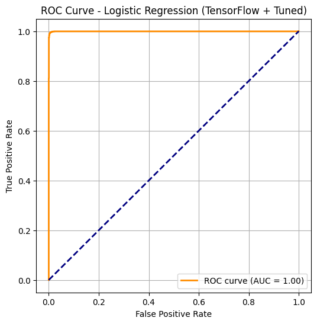

```python
# Logistic Regression with Keras + TensorFlow + Hyperparameter Tuning

import tensorflow as tf
import keras_tuner as kt
from sklearn.metrics import (
    accuracy_score, precision_score, recall_score, f1_score,
    roc_curve, auc, confusion_matrix
)


X_train_numeric = X_train.select_dtypes(include=np.number)
X_test_numeric = X_test.select_dtypes(include=np.number)

X_train_tf = tf.constant(X_train_numeric.values, dtype=tf.float32)
X_test_tf = tf.constant(X_test_numeric.values, dtype=tf.float32)
y_train_tf = tf.constant(y_train, dtype=tf.float32) # y_train is already reshaped
y_test_tf = tf.constant(y_test, dtype=tf.float32)   # y_test is already reshaped


def build_model(hp):
    model = tf.keras.Sequential()
    # Logistic Regression layer
    model.add(tf.keras.layers.Dense(
        units=1,
        activation='sigmoid',
        input_shape=(X_train_tf.shape[1],)
    ))

    # Hyperparameter tuning: learning rate
    hp_learning_rate = hp.Choice('learning_rate', values=[1e-2, 1e-3, 1e-4])
    optimizer = tf.keras.optimizers.Adam(learning_rate=hp_learning_rate)

    model.compile(optimizer=optimizer, loss='binary_crossentropy', metrics=['accuracy'])
    return model

# Hyperparameter Tuning

tuner = kt.RandomSearch(
    build_model,
    objective='val_accuracy',
    max_trials=5,
    executions_per_trial=2,
    directory='tuner_results',
    project_name='logistic_regression_tuning'
)

tuner.search(X_train_tf, y_train_tf, epochs=20, validation_split=0.2, verbose=1)

# Best hyperparameters
best_hps = tuner.get_best_hyperparameters(num_trials=1)[0]
print(f"Best Learning Rate: {best_hps.get('learning_rate')}")


best_model = tuner.hypermodel.build(best_hps)
history = best_model.fit(
    X_train_tf, y_train_tf,
    epochs=50,
    batch_size=32,
    validation_split=0.1,
    verbose=1
)

y_pred_prob_tf = best_model.predict(X_test_tf).flatten()
y_pred_tf = (y_pred_prob_tf >= 0.5).astype(int)

accuracy_tf = accuracy_score(y_test_tf, y_pred_tf)
precision_macro = precision_score(y_test_tf, y_pred_tf, average='macro')
precision_weighted = precision_score(y_test_tf, y_pred_tf, average='weighted')
recall_macro = recall_score(y_test_tf, y_pred_tf, average='macro')
recall_weighted = recall_score(y_test_tf, y_pred_tf, average='weighted')
f1_macro = f1_score(y_test_tf, y_pred_tf, average='macro')
f1_weighted = f1_score(y_test_tf, y_pred_tf, average='weighted')

print("\nTensorFlow Logistic Regression (Tuned) Metrics:")
print(f"Accuracy             : {accuracy_tf:.4f}")
print(f"Precision - Macro    : {precision_macro:.4f}, Weighted: {precision_weighted:.4f}")
print(f"Recall    - Macro    : {recall_macro:.4f}, Weighted: {recall_weighted:.4f}")
print(f"F1-Score - Macro     : {f1_macro:.4f}, Weighted: {f1_weighted:.4f}")

fpr, tpr, thresholds = roc_curve(y_test_tf, y_pred_prob_tf)
roc_auc = auc(fpr, tpr)

plt.figure(figsize=(6,6))
plt.plot(fpr, tpr, color='darkorange', lw=2, label=f'ROC curve (AUC = {roc_auc:.2f})')
plt.plot([0, 1], [0, 1], color='navy', lw=2, linestyle='--')
plt.xlabel('False Positive Rate')
plt.ylabel('True Positive Rate')
plt.title('ROC Curve - Logistic Regression (TensorFlow + Tuned)')
plt.legend(loc="lower right")
plt.grid(True)
plt.show()
```

**Logistic regression Confusion Matrix:**

This code displays the amount of accurate and inaccurate predictions for each class in the confusion matrix for the logistic regression model. By differentiating between clients with low and high spending levels, the matrix aids is assessing model performance beyond general correctness. It is simple to spot regions where the model performance well or misclassifies because each cell is labeled with the number of predictions, with colors indicating higher values. Understanding classification error, evaluating the proportion of true positives, true negatives, false positives, and false negative and directing enhancements in predicting performance all depend on the depiction.

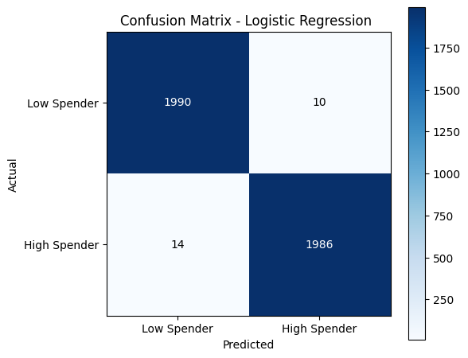

```python
from sklearn.metrics import confusion_matrix

cm = confusion_matrix(y_test_tf, y_pred_tf)

plt.figure(figsize=(6,5))
plt.imshow(cm, interpolation='nearest', cmap=plt.cm.Blues)
plt.title('Confusion Matrix - Logistic Regression ')
plt.colorbar()
classes = ['Low Spender', 'High Spender']
plt.xticks([0,1], classes)
plt.yticks([0,1], classes)

# Annotate cells
thresh = cm.max() / 2.
for i in range(cm.shape[0]):
    for j in range(cm.shape[1]):
        plt.text(j, i, format(cm[i, j], 'd'),
                 ha="center", va="center",
                 color="white" if cm[i, j] > thresh else "black")

plt.ylabel('Actual')
plt.xlabel('Predicted')
plt.tight_layout()
plt.show()
```

```python
!pip install keras-tuner
```

```
Downloading keras_tuner-1.4.7-py3-none-any.whl (129 kB)
   ━━━━━━━━━━━━━━━━━━━━━━━━━━━━━━━━━━━━━━━━ 129.1/129.1 kB 4.7 MB/s eta 0:00:00
Downloading kt_legacy-1.0.5-py3-none-any.whl (9.6 kB)
```

**Logistic Regression Model in Pytorch:**

To categorize clients as high spendors or low spendors, this code uses PyTorch to create logiostic Regression model. For effective trainig, the datset's numerical characteristics are transformed into PyTorch tensors and loaded in batches. One linear layer with sigmoid activation to produce probabilities make up the model. It is trained over 50 epoch with adam optimizer and binary cross entropy loss.

After training, predictions on the test set are evaluated using common classification measures like accuracy, precision, recall, f!-socre and ROC-AUC. The Roc curve illustrate the trade-off between the true positive rate and false positive rate, providing insight into the model's discriminative power.

```
PyTorch Logistic Regression Metrics:
Accuracy : 0.9942
Precision: 0.9920
Recall   : 0.9965
F1-Score : 0.9943
```

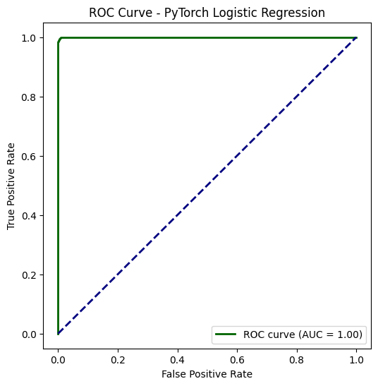

```python
# PyTorch Logistic Regression
import torch
import torch.nn as nn
from torch.utils.data import DataLoader, TensorDataset
from sklearn.metrics import accuracy_score, precision_score, recall_score, roc_curve, auc
from sklearn.metrics import f1_score

# Ensure all columns in X_train and X_test are numeric
X_train_numeric = X_train.select_dtypes(include=np.number)
X_test_numeric = X_test.select_dtypes(include=np.number)

# Convert to torch tensors
X_train_torch = torch.tensor(X_train_numeric.values, dtype=torch.float32)
y_train_torch = torch.tensor(y_train.reshape(-1,1), dtype=torch.float32) # Removed .values
X_test_torch = torch.tensor(X_test_numeric.values, dtype=torch.float32)
y_test_torch = torch.tensor(y_test.reshape(-1,1), dtype=torch.float32) # Removed .values

# Dataset and Loader
train_dataset = TensorDataset(X_train_torch, y_train_torch)
train_loader = DataLoader(train_dataset, batch_size=32, shuffle=True)

# Define model
class LogisticRegressionModel(nn.Module):
    def __init__(self, input_dim):
        super(LogisticRegressionModel, self).__init__()
        self.linear = nn.Linear(input_dim, 1)

    def forward(self, x):
        return torch.sigmoid(self.linear(x))

model_pt = LogisticRegressionModel(X_train_torch.shape[1])
criterion = nn.BCELoss()
optimizer = torch.optim.Adam(model_pt.parameters(), lr=0.01)

# Training loop
epochs = 50
for epoch in range(epochs):
    for X_batch, y_batch in train_loader:
        optimizer.zero_grad()
        outputs = model_pt(X_batch)
        loss = criterion(outputs, y_batch)
        loss.backward()
        optimizer.step()

# Predictions
with torch.no_grad():
    y_pred_prob_pt = model_pt(X_test_torch).numpy().flatten()
    y_pred_pt = (y_pred_prob_pt >= 0.5).astype(int)

# Metrics
accuracy_pt = accuracy_score(y_test, y_pred_pt)
precision_pt = precision_score(y_test, y_pred_pt)
recall_pt = recall_score(y_test, y_pred_pt)
f1_pt = f1_score(y_test, y_pred_pt)
print("PyTorch Logistic Regression Metrics:")
print(f"Accuracy : {accuracy_pt:.4f}")
print(f"Precision: {precision_pt:.4f}")
print(f"Recall   : {recall_pt:.4f}")
print(f"F1-Score : {f1_pt:.4f}")
# ROC Curve
fpr_pt, tpr_pt, thresholds_pt = roc_curve(y_test, y_pred_prob_pt)
roc_auc_pt = auc(fpr_pt, tpr_pt)

plt.figure(figsize=(6,6))
plt.plot(fpr_pt, tpr_pt, color='darkgreen', lw=2, label=f'ROC curve (AUC = {roc_auc_pt:.2f})')
plt.plot([0, 1], [0, 1], color='navy', lw=2, linestyle='--')
plt.xlabel('False Positive Rate')
plt.ylabel('True Positive Rate')
plt.title('ROC Curve - PyTorch Logistic Regression')
plt.legend(loc="lower right")
plt.show()
```

**Hyperparameter-Tuning Decision Tree Model:**

This code uses GridSearchCV to determine the ideal hyperparameters and applies a Decision Tree model to categorize clients as high spenders or low spenders. To enhance model performance, a parameter grid establishes ranhes for max depth, min samples split, min sample leaf, and criterion. Five -fold cross validation is used to determine the optimal model based on the macro F1-score. Metrics including accuracy, precision, recall, F1-score, and ROC-AUC are used to assess predicitions following training.

To see how well the model can differentiate between the two classes, the ROC curve is presented. By ensuring that the tree is neither overfitting nor underfitting, hyperparameter tuning enhances the tree's ability to generalize the test data.

```
Fitting 5 folds for each of 160 candidates, totalling 800 fits
Best Parameters for Decision Tree: {'criterion': 'entropy', 'max_depth': 10, 'min_samples_leaf': 10, 'min_samples_split': 2}

Decision Tree Metrics after Hyperparameter Tuning:
Accuracy : 0.9835
Precision - Macro: 0.9835, Weighted: 0.9835
Recall    - Macro: 0.9835, Weighted: 0.9835
F1-Score - Macro: 0.9835, Weighted: 0.9835
```

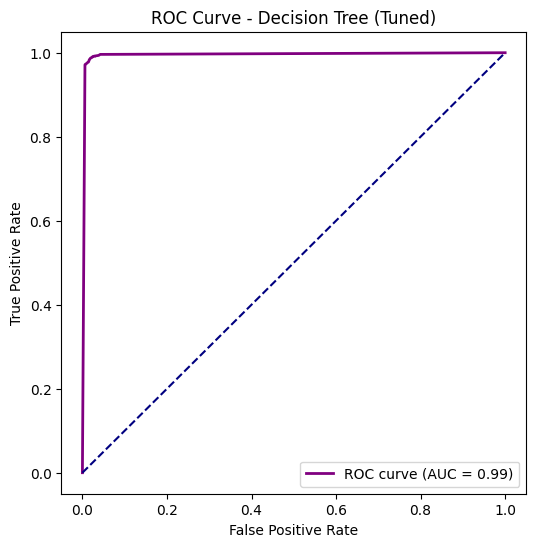

```python
from sklearn.tree import DecisionTreeClassifier
from sklearn.metrics import accuracy_score, precision_score, recall_score, f1_score, roc_curve, auc
from sklearn.model_selection import GridSearchCV

# Define parameter grid for Decision Tree
param_grid = {
    'max_depth': [3, 5, 7, 10, None],
    'min_samples_split': [2, 5, 10, 20],
    'min_samples_leaf': [1, 2, 5, 10],
    'criterion': ['gini', 'entropy']
}

# Initialize Decision Tree with GridSearchCV
grid_search = GridSearchCV(
    estimator=DecisionTreeClassifier(random_state=42),
    param_grid=param_grid,
    cv=5,
    scoring='f1_macro',
    n_jobs=-1,
    verbose=1
)

# Train model
grid_search.fit(X_train, y_train)

# Best model
best_dt_model = grid_search.best_estimator_
print("Best Parameters for Decision Tree:", grid_search.best_params_)

# Predictions
y_pred_dt = best_dt_model.predict(X_test)
y_pred_prob_dt = best_dt_model.predict_proba(X_test)[:,1]

# Metrics
accuracy_dt = accuracy_score(y_test, y_pred_dt)
precision_macro_dt = precision_score(y_test, y_pred_dt, average='macro')
precision_weighted_dt = precision_score(y_test, y_pred_dt, average='weighted')
recall_macro_dt = recall_score(y_test, y_pred_dt, average='macro')
recall_weighted_dt = recall_score(y_test, y_pred_dt, average='weighted')
f1_macro_dt = f1_score(y_test, y_pred_dt, average='macro')
f1_weighted_dt = f1_score(y_test, y_pred_dt, average='weighted')

print("\nDecision Tree Metrics after Hyperparameter Tuning:")
print(f"Accuracy : {accuracy_dt:.4f}")
print(f"Precision - Macro: {precision_macro_dt:.4f}, Weighted: {precision_weighted_dt:.4f}")
print(f"Recall    - Macro: {recall_macro_dt:.4f}, Weighted: {recall_weighted_dt:.4f}")
print(f"F1-Score - Macro: {f1_macro_dt:.4f}, Weighted: {f1_weighted_dt:.4f}")

# ROC Curve
fpr_dt, tpr_dt, _ = roc_curve(y_test, y_pred_prob_dt)
roc_auc_dt = auc(fpr_dt, tpr_dt)

plt.figure(figsize=(6,6))
plt.plot(fpr_dt, tpr_dt, color='purple', lw=2, label=f'ROC curve (AUC = {roc_auc_dt:.2f})')
plt.plot([0,1], [0,1], color='navy', linestyle='--')
plt.xlabel('False Positive Rate')
plt.ylabel('True Positive Rate')
plt.title('ROC Curve - Decision Tree (Tuned)')
plt.legend(loc="lower right")
plt.show()
```

**Decision Tree confusion Matrix:**

The Confusion Matrix for Decision Tree model is visualized by this code, which indicates the proportion of customers taht were rightly or wrongly categorized as high spenders or low spenders. The model's classification performance can be rapidly evaluated thanks to the annotation of the number of predictions in each cell and the color intensity, which indicates the magnitude.

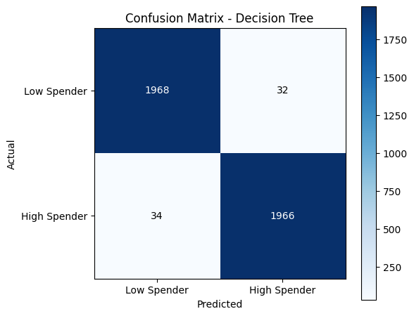

```python
from sklearn.metrics import confusion_matrix

# Confusion Matrix
cm_dt = confusion_matrix(y_test, y_pred_dt)

plt.figure(figsize=(6,5))
plt.imshow(cm_dt, interpolation='nearest', cmap=plt.cm.Blues)
plt.title('Confusion Matrix - Decision Tree')
plt.colorbar()
classes = ['Low Spender', 'High Spender']
plt.xticks([0,1], classes)
plt.yticks([0,1], classes)

# Annotate cells
thresh = cm_dt.max() / 2.
for i in range(cm_dt.shape[0]):
    for j in range(cm_dt.shape[1]):
        plt.text(j, i, format(cm_dt[i, j], 'd'),
                 ha="center", va="center",
                 color="white" if cm_dt[i, j] > thresh else "black")

plt.ylabel('Actual')
plt.xlabel('Predicted')
plt.tight_layout()
plt.show()
```

**Evaluation of the K-Nearest Neighnors (KNN Model):**

This code dertermines wheather a consumer is a high or low spender by training a K-Nearest Neighbors (KNN) classifer. It depicts the ROC curve to sbhow the trade off between true positve and false positive rates and assesses the model using metrics like accuracy, precision, recall, and F1-score (both macro and weighted averages). The model's overall capicty to differentiate between the two calsses is indicated by the ROC-AUC value.

Each client is categorized by the KNN model according to the feature space's nearby neighbor's majority class. Since n_neighbors=5 is applied here, the prediction is influenced by five closest samples. plotting ROC curve using probability output gives information about how well the model performs at various categorization levels.

By comparing KNN with other models, such as Decision Tree and Logistic Regression, this evaluation makes it possible to choose the best algorithm for identifying clients who spend a lot of money.

```
K-Nearest Neighbors Metrics:
Accuracy : 0.9740
Precision - Macro: 0.9741, Weighted: 0.9741
Recall    - Macro: 0.9740, Weighted: 0.9740
F1-Score - Macro: 0.9740, Weighted: 0.9740
```

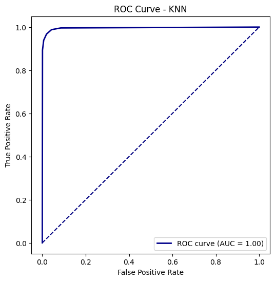

```python
from sklearn.neighbors import KNeighborsClassifier
from sklearn.metrics import accuracy_score, precision_score, recall_score, f1_score, roc_curve, auc, confusion_matrix

knn_model = KNeighborsClassifier(n_neighbors=5)  # You can tune n_neighbors

# Train the model
knn_model.fit(X_train, y_train)

# Predictions
y_pred_knn = knn_model.predict(X_test)
y_pred_prob_knn = knn_model.predict_proba(X_test)[:,1]  # Probability for ROC
accuracy_knn = accuracy_score(y_test, y_pred_knn)
precision_macro_knn = precision_score(y_test, y_pred_knn, average='macro')
precision_weighted_knn = precision_score(y_test, y_pred_knn, average='weighted')
recall_macro_knn = recall_score(y_test, y_pred_knn, average='macro')
recall_weighted_knn = recall_score(y_test, y_pred_knn, average='weighted')
f1_macro_knn = f1_score(y_test, y_pred_knn, average='macro')
f1_weighted_knn = f1_score(y_test, y_pred_knn, average='weighted')
f1_knn = f1_score(y_test, y_pred_knn)

print("\nK-Nearest Neighbors Metrics:")
print(f"Accuracy : {accuracy_knn:.4f}")
print(f"Precision - Macro: {precision_macro_knn:.4f}, Weighted: {precision_weighted_knn:.4f}")
print(f"Recall    - Macro: {recall_macro_knn:.4f}, Weighted: {recall_weighted_knn:.4f}")
print(f"F1-Score - Macro: {f1_macro_knn:.4f}, Weighted: {f1_weighted_knn:.4f}")

fpr_knn, tpr_knn, _ = roc_curve(y_test, y_pred_prob_knn)
roc_auc_knn = auc(fpr_knn, tpr_knn)

plt.figure(figsize=(6,6))
plt.plot(fpr_knn, tpr_knn, color='darkblue', lw=2, label=f'ROC curve (AUC = {roc_auc_knn:.2f})')
plt.plot([0,1], [0,1], color='navy', linestyle='--')
plt.xlabel('False Positive Rate')
plt.ylabel('True Positive Rate')
plt.title('ROC Curve - KNN')
plt.legend(loc="lower right")
plt.show()
```

**Confusion Matrix:**

In order to visualize how successfully the K-Nearest Neighbors (KNN) model categorizes consumers as either low or high spenders, this code creates a confusion matrix for the model. With color intensity denoting frequency, the matrix displays the number of accurate and incurreate forecasts for each class. The count is marked in each cell, and the font color is adjusted for readability using a threshold. In order to facilitate model review and comparison with other algorithms, this visualization helps rapidly evaluate the model's performance by showing places where KNN properly identifies consumer spending behavior and where it may misclassify.

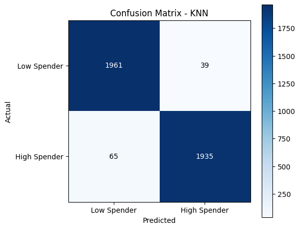

```python
cm_knn = confusion_matrix(y_test, y_pred_knn)

plt.figure(figsize=(6,5))
plt.imshow(cm_knn, interpolation='nearest', cmap=plt.cm.Blues)
plt.title('Confusion Matrix - KNN')
plt.colorbar()
classes = ['Low Spender', 'High Spender']
plt.xticks([0,1], classes)
plt.yticks([0,1], classes)

# Annotate cells
thresh = cm_knn.max() / 2.
for i in range(cm_knn.shape[0]):
    for j in range(cm_knn.shape[1]):
        plt.text(j, i, format(cm_knn[i, j], 'd'),
                 ha="center", va="center",
                 color="white" if cm_knn[i, j] > thresh else "black")

plt.ylabel('Actual')
plt.xlabel('Predicted')
plt.tight_layout()
plt.show()
```

**Result table:**

This code evaluates how well several classification models-K-Nearest Neighbors, Decision Tree, PyTorch Logistic regression, and Tensorflow logistic Regression-perform on the test datset. For every model, it computes important assessment measures like accuracy, precision, recall, f1-score and AUC. For concise, tabular summary, the findings are first arranged into dictionary and then transformed into a pandas dataframe.

This makes it simple to compare the model's efficay across several criteria, which aids in determine which model performs best at forecasting consumer spending patterns.

```python
from sklearn.metrics import precision_score, recall_score, f1_score

precision_macro_tf = precision_score(y_test_tf, y_pred_tf, average='macro')
precision_weighted_tf = precision_score(y_test_tf, y_pred_tf, average='weighted')
recall_macro_tf = recall_score(y_test_tf, y_pred_tf, average='macro')
recall_weighted_tf = recall_score(y_test_tf, y_pred_tf, average='weighted')
f1_macro_tf = f1_score(y_test_tf, y_pred_tf, average='macro')
f1_weighted_tf = f1_score(y_test_tf, y_pred_tf, average='weighted')

precision_macro_pt = precision_score(y_test, y_pred_pt, average='macro')
precision_weighted_pt = precision_score(y_test, y_pred_pt, average='weighted')
recall_macro_pt = recall_score(y_test, y_pred_pt, average='macro')
recall_weighted_pt = recall_score(y_test, y_pred_pt, average='weighted')
f1_macro_pt = f1_score(y_test, y_pred_pt, average='macro')
f1_weighted_pt = f1_score(y_test, y_pred_pt, average='weighted')


# Create a dictionary with results
results = {
    "Model": [
        "Logistic Regression (TF)",
        "Logistic Regression (PyTorch)",
        "Decision Tree",
        "K-Nearest Neighbors"
    ],
    "Accuracy": [
        accuracy_tf,
        accuracy_pt,
        accuracy_dt,
        accuracy_knn
    ],
    "Precision (Macro)": [
        precision_macro_tf,
        precision_macro_pt,
        precision_macro_dt,
        precision_macro_knn
    ],
    "Precision (Weighted)": [
        precision_weighted_tf,
        precision_weighted_pt,
        precision_weighted_dt,
        precision_weighted_knn
    ],
    "Recall (Macro)": [
        recall_macro_tf,
        recall_macro_pt,
        recall_macro_dt,
        recall_macro_knn
    ],
    "Recall (Weighted)": [
        recall_weighted_tf,
        recall_weighted_pt,
        recall_weighted_dt,
        recall_weighted_knn
    ],
    "F1-Score (Macro)": [
        f1_macro_tf,
        f1_macro_pt,
        f1_macro_dt,
        f1_macro_knn
    ],
    "F1-Score (Weighted)": [
        f1_weighted_tf,
        f1_weighted_pt,
        f1_weighted_dt,
        f1_weighted_knn
    ],
    "AUC": [
        roc_auc, # Correct variable name for TF AUC
        roc_auc_pt,
        roc_auc_dt,
        roc_auc_knn
    ]
}

# Convert to DataFrame
results_df = pd.DataFrame(results)

# Display the results table
print("Model Performance Comparison:")
display(results_df)
```

```
Model Performance Comparison:
```

|  | Model | Accuracy | Precision (Macro) | Precision (Weighted) | Recall (Macro) | Recall (Weighted) | F1-Score (Macro) | F1-Score (Weighted) | AUC |
| --- | --- | --- | --- | --- | --- | --- | --- | --- | --- |
| 0 | Logistic Regression (TF) | 0.99400 | 0.994002 | 0.994002 | 0.99400 | 0.99400 | 0.994000 | 0.994000 | 0.999307 |
| 1 | Logistic Regression (PyTorch) | 0.99425 | 0.994260 | 0.994260 | 0.99425 | 0.99425 | 0.994250 | 0.994250 | 0.999844 |
| 2 | Decision Tree | 0.98350 | 0.983500 | 0.983500 | 0.98350 | 0.98350 | 0.983500 | 0.983500 | 0.994517 |
| 3 | K-Nearest Neighbors | 0.97400 | 0.974080 | 0.974080 | 0.97400 | 0.97400 | 0.973999 | 0.973999 | 0.995697 |

**Dashboard of Confusion Matrix for all Models:**

The Tensorflow Logistic Regression, PyTorch Logistic Regression, Decision Tree, and K-Nearest Neighbors models are the four models for which this code creates a comparative dashboard of confusion matrices. To clearly compare how effectively each model predicts low and high spendors, each subplot shows the number of true positives, true negatives, false positives, false negatives for its corresponding model.

An intutive comprehension of classification performance is made possible by annotated values and color shading, which show which model make fewer mistakes and where misclassifications happen. Rapid evaluation of the model's advantage and disadvantage in forecasting consumer spending patterns is made possible by the combined visualization.

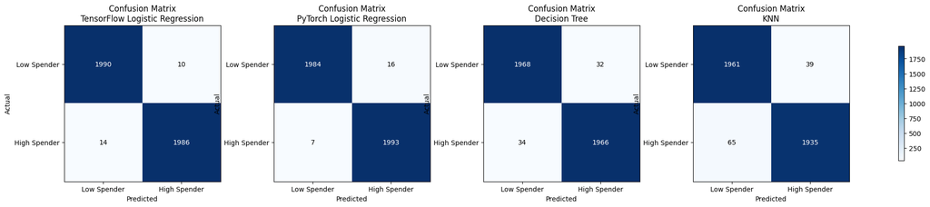

```python
from sklearn.metrics import confusion_matrix
# Compute confusion matrices
cm_tf = confusion_matrix(y_test, y_pred_tf)      # TensorFlow Logistic
cm_pt = confusion_matrix(y_test, y_pred_pt)      # PyTorch Logistic
cm_dt = confusion_matrix(y_test, y_pred_dt)      # Decision Tree
cm_knn = confusion_matrix(y_test, y_pred_knn)    # KNN

# Titles for each subplot
titles = ['TensorFlow Logistic Regression', 'PyTorch Logistic Regression', 'Decision Tree', 'KNN']
cms = [cm_tf, cm_pt, cm_dt, cm_knn]

classes = ['Low Spender', 'High Spender']

# Create dashboard
fig, axes = plt.subplots(1, 4, figsize=(22,5))

for ax, cm, title in zip(axes, cms, titles):
    im = ax.imshow(cm, interpolation='nearest', cmap=plt.cm.Blues)
    ax.set_title(f'Confusion Matrix\n{title}')
    ax.set_xticks([0,1])
    ax.set_yticks([0,1])
    ax.set_xticklabels(classes)
    ax.set_yticklabels(classes)

    # Annotate cells
    thresh = cm.max() / 2.
    for i in range(cm.shape[0]):
        for j in range(cm.shape[1]):
            ax.text(j, i, format(cm[i, j], 'd'),
                    ha="center", va="center",
                    color="white" if cm[i, j] > thresh else "black")

    ax.set_ylabel('Actual')
    ax.set_xlabel('Predicted')

fig.tight_layout()
fig.colorbar(im, ax=axes.ravel().tolist(), shrink=0.6)
plt.show()
```

**Model Performance Metrics by Radar Visualization:**

For Machine Learning Models Logistic Regression (TenserFlow & PyTorch), Decision Tree, and KNN- are compared in terms of performance using five key assessment measures in this radar chart: Accuracy, Precision (Macro), Recall(Macro), F1-Score and AUC. One measure is represented by each axis, and the polygons created by joining model scores show the relative advantages and disadvantages of each metric.

It is simpler to observe which models perform better in particular domains and which are more balanced across all measures thanks to the circular structure. For instance, models with irregular polygons show trade-offs between precision, recall, or generalization ability, whereas models with larger, more uniformly distributed shapes function consistently. A clear, comprehensive picture of model performance is given by this representation, faciliating better model selection.

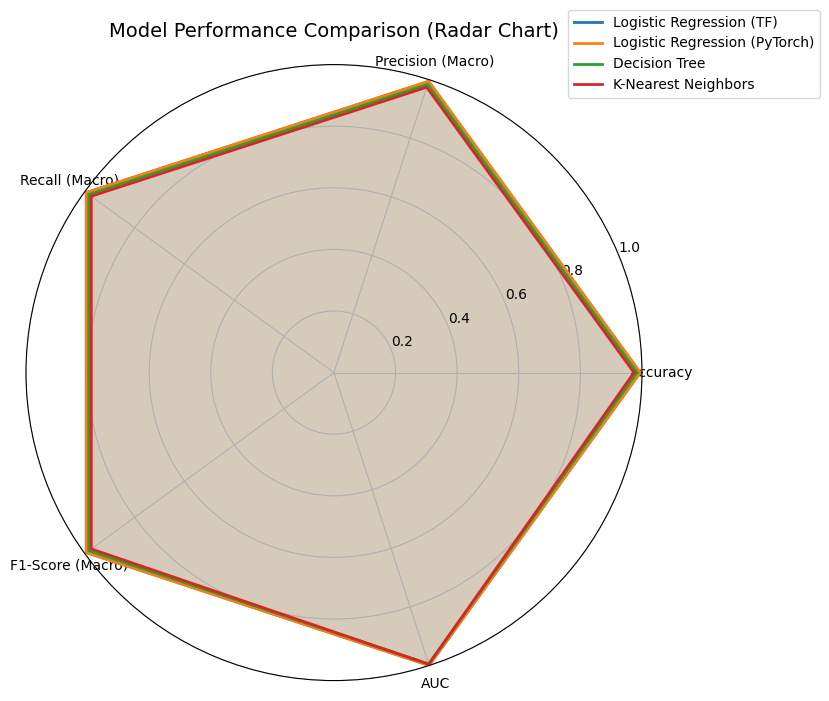

```python
# Metrics to visualize
metrics = ["Accuracy", "Precision (Macro)", "Recall (Macro)", "F1-Score (Macro)", "AUC"]
models = results_df["Model"].tolist()
values = results_df[metrics].values
num_vars = len(metrics)
angles = np.linspace(0, 2 * np.pi, num_vars, endpoint=False).tolist()
angles += angles[:1]
plt.figure(figsize=(8,8))
ax = plt.subplot(111, polar=True)
# Plot each model
for i, model in enumerate(models):
    stats = values[i].tolist()
    stats += stats[:1]
    ax.plot(angles, stats, label=model, linewidth=2)
    ax.fill(angles, stats, alpha=0.1)
ax.set_xticks(angles[:-1])
ax.set_xticklabels(metrics)

ax.set_ylim(0, 1)
plt.title("Model Performance Comparison (Radar Chart)", size=14, pad=20)
plt.legend(loc="upper right", bbox_to_anchor=(1.3, 1.1))
plt.show()
```

**The Significance of Logistic Regression Features (TensorFlow):**

In order to assess feature importance, this phase extracts and displays the coefficients taht the TenserFlow Logistic Regression model has learned. the coefficients show how strongly and in which direction each feature influences the prediction of a customer's status as a higher or lower spender. features that raise the probalitlity of being categorized as a high spender are indicated by positive coefficients, whilst charcteristics that decrease this probability are indicated by negative coefficients.

Plotting top 15 features allows us to rapidly determine which factors have the greatest influence on consumer buying patterns, which facilitates the creation of business insights and decision-making.

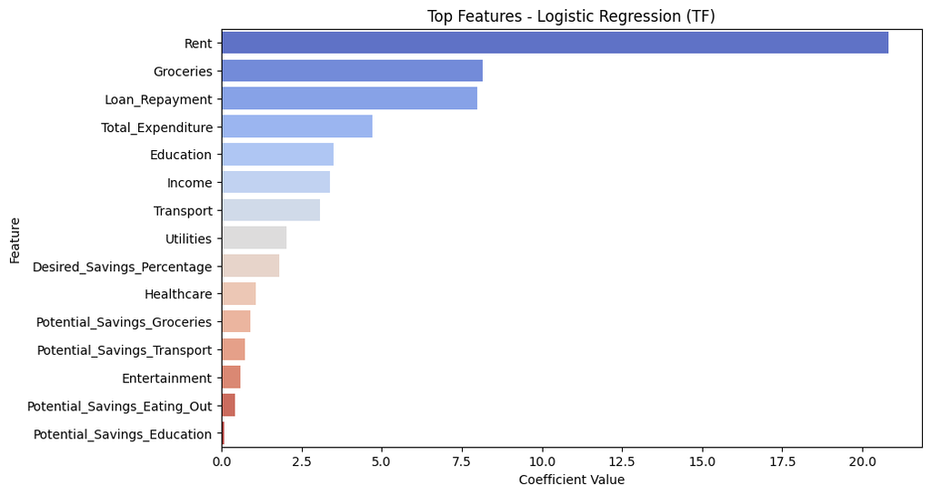

```
                         Feature  Coefficient
3                           Rent    20.820494
6                      Groceries     8.146820
4                 Loan_Repayment     7.983231
25             Total_Expenditure     4.703376
12                     Education     3.505212
0                         Income     3.393868
7                      Transport     3.073144
10                     Utilities     2.018429
14    Desired_Savings_Percentage     1.796930
11                    Healthcare     1.082967
17   Potential_Savings_Groceries     0.889906
18   Potential_Savings_Transport     0.720595
9                  Entertainment     0.589312
19  Potential_Savings_Eating_Out     0.434885
23   Potential_Savings_Education     0.078067
```

```python
weights = best_model.layers[0].get_weights()[0].flatten()
feature_names = X_train_numeric.columns

coef_df = pd.DataFrame({
    'Feature': feature_names,
    'Coefficient': weights
}).sort_values(by='Coefficient', ascending=False)

plt.figure(figsize=(10,6))
sns.barplot(x='Coefficient', y='Feature', data=coef_df.head(15), palette='coolwarm')
plt.title("Top Features - Logistic Regression (TF)")
plt.xlabel("Coefficient Value")
plt.ylabel("Feature")
plt.show()

print(coef_df.head(15))
```

**Business Knowledge:**

Age group, city tier, dependents, and occupation are all associated with high expenditure. While larger households devote more to necessities, younger earners and Tier 1-2 city dwellers spend more. Opportunities for customized credit offer, saving plans, and financial counseling are made possible by these trends.

Furthermore, vocations with more disposable income tend to spend more on entertainment and dining out, among other lifestyle categories. businesses can create specialized financial products, such personalized credit card or budgeting tools, to promote more frugal spending and boost consumer involvement by identifying these groups.

**Conclusion:**

These results offer useful business insights that allow for more focused suggestion, such as budgeting techniques, credit offers, and customized saving plans. All things considered, the study shows how data-driven methods may help with consumer segmentation, financial decision-making, and creation of customized financial products.